# 1 TUGAS KLASIFIKASI DATA PROYEK SAINS DATA - B

Nama : Alif Dhaifullah Ramadhan  
NIM : 210411100020 Kelas : B

## 1.1 BUSSINESS UNDERSTANDING

### 1.1.1 TUJUAN PROYEK

**memprediksi apakah seorang pasien memiliki risiko penyakit stroke berdasarkan model terbaik yang dihasilkan dari klasifikasi penyakit stroke**

Untuk memprediksi penyaki stroke dapat dilihat dari ciri-ciri sebagai berikut:

### 1.1.2 DESKRIPSI FITUR

- **sex(jenis kelamin pasien)**
- **age(umur pasien) (dalam tahun)**
- **hypertension(riwayat darah tinggi) (pernah atau tidak)**
- **heart_disease(riwayat penyakit jantung) (pernah atau tidak)**
- **ever_maried(riwayat menikah) (penah atau tidak)**
- **work_type(pekerjaan pasien)**
- **Residence_level(tipe tampat tinggal) (desa atau kota)**
- **avg_glucose_level(satuan dari level rata rata gula)(mg/dl)**
- **bmi(satuan dari indeks masa tubuh)(kg/m2)**
- **smoking_status(riwayat merokok)(pernah atau tidak)**

# 2 2. DATA UNDERSTANDING

### 2.0.1 Teknik Pengumpulan Data

Studi ini akan membahas prediksi stroke berdasarkan data survey yang dilakukan oleh CDC pada tahun 2015

Tentang Stroke yang merupakan penyebab kematian nomor 2 secara global dan bertanggung jawab atas 11% dari total kematian yang terjadi di dunia. data ini diperoleh oleh cdc berdasarkan surver yang lakukan pada rumah sakit di amerika serikat dan disupport oleh data yang dimiliki oleh WHO.

Jumlah Dataset sebanyak 40910 dengan rincian sebagai berikut: - positive stroke (1) = 20460 data - negative stroke (0) = 20450 data

**MISSING VALUES** > - Didalam data sampel stroke setelah dilakukan pengecekan nilai tidak ditemukan data dengan nilai yang hilang (Missing Values).

**OUTLIER PADA DATA** > - Setelah dilakukan pengecekan outlier dengan menggunakan teknik Local Outlier Factor diketahui terdapat 271 data yang terdeteksi mengandung outlier.

**PROPORSI JUMLAH KELAS PADA DATA** > - Berdasarkan jumlah data pada setiap kelas yang telah di definisikan sebelumnya, dapat diketahui bahwasan nya pada data jumlah masing-masing kelas telah seimbang dan meiliki kualitas bagus

Tipe dari data disetiap kolomnya sebagai berikut: 1. Tipe Rasio : > - age > - avg_glucose_level > - bmi

2. Tipe Ordinal > - sex > - heypertension > - heart desease > - ever married > - work type > - residence level > - smoking status

### 2.0.2 DESKRIPSI FITUR

- **sex**: berisikan jenis kelamin dari pasien
- **bmi**: Angka BMI normal berada pada kisaran 18,5-25. Jika angka BMI melebihi 25, kamu memiliki berat badan berlebih. Sementara itu, jika angka BMI berada di bawah 18 berarti berat badan kurang. obesitasi merupakan salah satu faktor risiko stroke dikarenakan peradangan jaringan tubuh akibat lemak berlebih. kondisi ini dapat memicu masalah aliran darah dan peningkatan risiko penyumbatan darah. Nah, kondisi ini yang ujung-ujungnya menyebabkan stroke.
- **age (umur)**: Ada sejumlah faktor risiko penyakit stroke, diantaranya USIA. Penyakit stroke rata-rata menyerang seseorang yang berusia di atas 60 tahun.
- **hypertension (hipertensi)**: suatu keadaan dimana tekanan darah sistolik pada tubuh seseorang lebih dari atau sama dengan 140 mmHg dan atau tekanan darah diastolik lebih dari atau sama dengan 90 mmHg.
- **heart disease (penyakit jantung)**: kondisi ketika bagian jantung yang meliputi pembuluh darah jantung, selaput jantung, katup jantung, dan otot jantung mengalami gangguan.
- **ever married (pernah menikah)**: Faktor utama penyebab stroke adalah faktor genetik. Faktor genetik adalah faktor keturunan yang disebabkan oleh salah satu anggota keluarga. Umumnya, bagi yang menderita penyakit stroke ini, jika dari faktor genetik, sangat sulit untuk disembuhkan.
- **work type (jenis pekerjaan)**: Jenis pekerjaan juga salah satu faktor risiko terjadinya stroke. dikarenakan pekerjaan dengan aktivitas fisik yang lebih rendah rentan terkana stroke dibandingan dengan pekerjaan yang memiliki aktivitas fisik dalam jumlah sedang.
- **residence type (tipe tempat tinggal)**: Tempat tinggal juga mempengaruhi terjadinya stroke. karena prevalensi stroke diperkotaan lebih tinggi (8,2%) dibandingkan dengan daerah pedesaan (5,7%).
- **avg glucose level (kadar glukosa rata-rata)**: Kandungan gula berlebih dalam darah dapat menyebabkan pembuluh darah menjadi kaku dan penumpukan timbunan lemak. Kondisi inilah yang memicu penggumpalan darah yang bila berpindah ke otak dapat menyebabkan stroke.
- **smoking status (status merokok)**: status merokok sangat mempengaruhi terjadinya stroke. Karena merokok bisa mengakibatkan berbagai masalah dengan aliran darah ke otak, dan menyumbang pembentukan gumpalan darah pada pembuluh darah – dan salah satu keduanya meningkatkan kemungkinan timbulnya serangan stroke.

Adapun hal - hal yang perlu dilakukan untuk memahami data, yakni :

1. Mendeskripsikan setiap fitur pada data
   - tipe data
   - deskripsi data
2. Mengidentifikasi missing values setiap fitur atau kolom
3. Eksplorasi data (grafikan fitur)
4. Mengidentifikasi outlier
5. Mengidentifikasi jumlah data (proporsi data perkelas -untuk mengetahui balancing dataset atau keseimbangan data per kelas)

## 2.1 Load Dataset

meng import/memanggil dataset stroke

```python
import pandas as pd

data = pd.read_csv('stroke_data.csv')
data.head(5)
```

|  | sex | age | hypertension | heart_disease | ever_married | work_type | Residence_type | avg_glucose_level | bmi | smoking_status | stroke |
| --- | --- | --- | --- | --- | --- | --- | --- | --- | --- | --- | --- |
| 0 | 1.0 | 63.0 | 0 | 1 | 1 | 4 | 1 | 228.69 | 36.6 | 1 | 1 |
| 1 | 1.0 | 42.0 | 0 | 1 | 1 | 4 | 0 | 105.92 | 32.5 | 0 | 1 |
| 2 | 0.0 | 61.0 | 0 | 0 | 1 | 4 | 1 | 171.23 | 34.4 | 1 | 1 |
| 3 | 1.0 | 41.0 | 1 | 0 | 1 | 3 | 0 | 174.12 | 24.0 | 0 | 1 |
| 4 | 1.0 | 85.0 | 0 | 0 | 1 | 4 | 1 | 186.21 | 29.0 | 1 | 1 |

```python
# Rincian dataset (banyak data dan kolom)

print("Banyaknya data : ", data.shape[0])
print("Banyaknya kolom : ", data.shape[1])
```

```
Banyaknya data :  40910
Banyaknya kolom :  11
```

```python
kelas_counts = data['stroke'].value_counts()
print(kelas_counts)
```

```
stroke
1    20460
0    20450
Name: count, dtype: int64
```

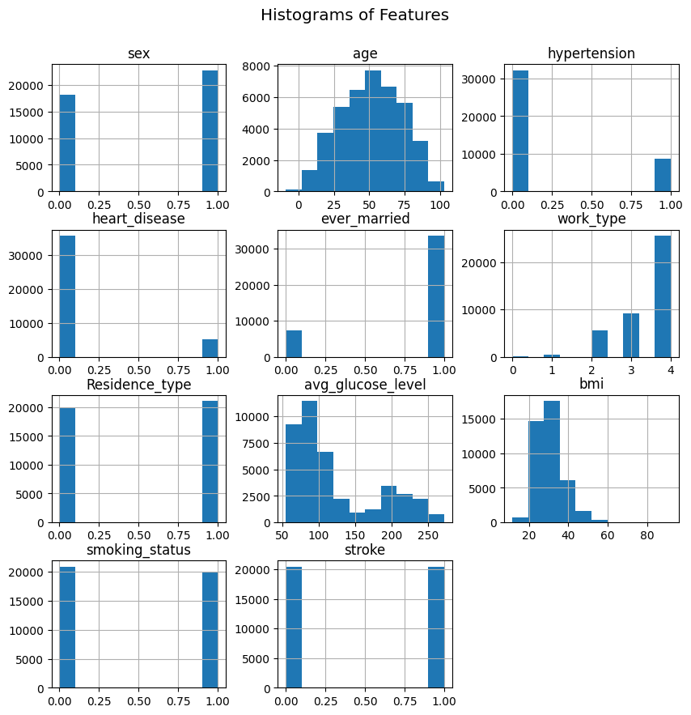

```python
import matplotlib.pyplot as plt


data.hist(figsize=(10, 10))
plt.suptitle('Histograms of Features', x=0.5, y=0.95, ha='center', fontsize='x-large')
plt.show()
```

## 2.2 Mendeskripsikan setiap fitur

mendeskripsikan fitur apa saja yang ada pada fitur dataset stroke

```python
data.columns
```

```
Index(['sex', 'age', 'hypertension', 'heart_disease', 'ever_married',
       'work_type', 'Residence_type', 'avg_glucose_level', 'bmi',
       'smoking_status', 'stroke'],
      dtype='object')
```

### 2.2.1 Tipe data

```python
data.dtypes
```

```
sex                  float64
age                  float64
hypertension           int64
heart_disease          int64
ever_married           int64
work_type              int64
Residence_type         int64
avg_glucose_level    float64
bmi                  float64
smoking_status         int64
stroke                 int64
dtype: object
```

Berikut Macam - Macam Data yang ada pada data ini.

### 2.2.2 Deskripsi data

- sex: berisi data jenis kelamin dari pasien
- bmi: Angka BMI normal berada pada kisaran 18,5-25. Jika angka BMI melebihi 25, kamu memiliki berat badan berlebih. Sementara itu, jika angka BMI berada di bawah 18 berarti berat badan kurang. obesitasi merupakan salah satu faktor risiko stroke dikarenakan peradangan jaringan tubuh akibat lemak berlebih. kondisi ini dapat memicu masalah aliran darah dan peningkatan risiko penyumbatan darah. Nah, kondisi ini yang ujung-ujungnya menyebabkan stroke.
- age (umur): ada sejumlah faktor risiko penyakit stroke, diantaranya USIA. Penyakit stroke rata-rata menyerang seseorang yang berusia di atas 60 tahun.
- hypertension (hipertensi): suatu keadaan dimana tekanan darah sistolik pada tubuh seseorang lebih dari atau sama dengan 140 mmHg dan atau tekanan darah diastolik lebih dari atau sama dengan 90 mmHg.
- heart disease (penyakit jantung): kondisi ketika bagian jantung yang meliputi pembuluh darah jantung, selaput jantung, katup jantung, dan otot jantung mengalami gangguan.
- ever married (pernah menikah): Faktor utama penyebab stroke adalah faktor genetik. Faktor genetik adalah faktor keturunan yang disebabkan oleh salah satu anggota keluarga. Umumnya, bagi yang menderita penyakit stroke ini, jika dari faktor genetik, sangat sulit untuk disembuhkan.
- work type (jenis pekerjaan): jenis pekerjaan juga salah satu faktor risiko terjadinya stroke. dikarenakan pekerjaan dengan aktivitas fisik yang lebih rendah rentan terkana stroke dibandingan dengan pekerjaan yang memiliki aktivitas fisik dalam jumlah sedang.
- residence type (tipe tempat tinggal): tempat tinggal juga mempengaruhi terjadinya stroke. karena prevalensi stroke diperkotaan lebih tinggi (8,2%) dibandingkan dengan daerah pedesaan (5,7%).
- avg glucose level (kadar glukosa rata-rata): Kandungan gula berlebih dalam darah dapat menyebabkan pembuluh darah menjadi kaku dan penumpukan timbunan lemak. Kondisi inilah yang memicu penggumpalan darah yang bila berpindah ke otak dapat menyebabkan stroke.
- smoking status (status merokok): status merokok sangat mempengaruhi terjadinya stroke. Karena merokok bisa mengakibatkan berbagai masalah dengan aliran darah ke otak, dan menyumbang pembentukan gumpalan darah pada pembuluh darah – dan salah satu keduanya meningkatkan kemungkinan timbulnya serangan stroke.

## 2.3 Mengidentifikasi missing value

### 2.3.1 Missing value

mencari missing value atau data yang tidak bernilai pada dataset stroke

- data.isna(): Fungsi ini menghasilkan DataFrame yang memiliki struktur yang sama dengan data, tetapi dengan nilai boolean (True atau False) yang menunjukkan apakah setiap sel dalam DataFrame data adalah nilai yang hilang atau tidak. Nilai True menunjukkan bahwa sel tersebut merupakan nilai yang hilang, sedangkan nilai False menunjukkan bahwa sel tersebut memiliki nilai.
- .any(): Metode ini kemudian digunakan untuk menerapkan fungsi any ke setiap kolom DataFrame hasil dari data.isna(). Ini menghasilkan Seri (Series) dengan indeks berupa nama kolom, dan nilai True atau False untuk setiap kolom, menunjukkan apakah kolom tersebut memiliki setidaknya satu nilai yang hilang atau tidak.

```python
# Menghitung apakah ada nilai yang hilang dalam setiap kolom
missing_values = data.isna().any()

# Menampilkan hasil
print("Apakah ada nilai yang hilang dalam setiap kolom:")
print(missing_values)
```

```
Apakah ada nilai yang hilang dalam setiap kolom:
sex                  False
age                  False
hypertension         False
heart_disease        False
ever_married         False
work_type            False
Residence_type       False
avg_glucose_level    False
bmi                  False
smoking_status       False
stroke               False
dtype: bool
```

Noted : tidak ada *missing value* pada data

### 2.3.2 Duplikat data

mencari duplikat data yang terjadi pada dataset stroke dengan menggunakan

- data.duplicated(): Fungsi ini digunakan untuk menghasilkan serangkaian nilai boolean yang menunjukkan apakah setiap baris dalam DataFrame data adalah duplikat atau tidak. Nilai True menunjukkan bahwa baris tersebut merupakan duplikat, sementara nilai False menunjukkan bahwa baris tersebut tidak duplikat.
- .sum(): Metode ini kemudian digunakan untuk menjumlahkan nilai-nilai boolean yang dihasilkan oleh duplicated(). Jika suatu baris adalah duplikat, nilai booleannya adalah True yang dihitung sebagai 1, dan jika bukan duplikat, nilai booleannya adalah False yang dihitung sebagai 0.

```python
jumlah_duplikat = data.duplicated().sum()

# Menampilkan jumlah data yang duplikat
print("Jumlah data yang duplikat:", jumlah_duplikat)
```

```
Jumlah data yang duplikat: 1
```

## 2.4 Mengidentifikasi Outlier

Mencari data outlier pada dataset adalah langkah penting dalam analisis data untuk mengidentifikasi nilai-nilai yang berbeda secara signifikan dari pola umum dataset. Outlier adalah nilai yang jauh dari nilai-nilai lainnya dan dapat memiliki dampak besar pada hasil analisis statistik. Pada dataset kali ini saya menggunakan Local Outlier Factor untuk mencari outlier yang ada pada dataset stroke tersebut.

### 2.4.1 Local Outlier Factor

- Pengertian Local Outlier Factor(LOF):

LOF mengukur sejauh mana suatu observasi berbeda dari tetangga-tetangganya dalam hal kepadatan. Outlier diidentifikasi berdasarkan perbandingan antara kepadatan observasi tersebut dan kepadatan tetangganya. Jika suatu observasi memiliki LOF yang tinggi, maka itu dianggap sebagai outlier.

- Langkah-langkah Local Outlier Factor (LOF):
1. Hitung Jarak Antar Data dimana jarak yang dihitung adalah jarak titik yang akan dievaluasi dengan semua titik didalam satu baris. Perhitungan Jarak dilakukan menggunakan perhitungan jarak euclidean.

   $$\text{distance}(p, q) = \sqrt{\sum_{i=1}^{n}(p_i - q_i)^2}$$
   dimana :
   - p = titik yang akan dievaluasi
   - q = titik selain titik p
2. Hitung Kepadatan Lokal Setelah jarak diketahui, maka selanjutnya kepadatan lokal dari titik data tersebut perlu dihitung. Kepadatan lokal dapat dihitung dengan membandingkan jumlah titik-titik tetangga dalam jarak tertentu (radius) terhadap titik data yang sedang dievaluasi.

   $$\text{Local Density}(p) = \frac{\text{jumlah tetangga dalam radius}}{\text{jumlah total data}}$$
3. Hitung Local Reachability Density(LRD) Hitung kepadatan jarak (reachability distance) dari titik data (p) terhadap tetangganya (q). Local Reachability Density dari titik p terhadap tetangga q dihitung sebagai rata-rata dari jarak antara q dan p terhadap tetangga q:

   $$\text{reachdist}(p, q) = \max(\text{distance}(p, q), \text{radius})$$

   $$\text{Local Reachability Density}(p) = \frac{1}{\text{jumlah tetangga}} \sum_{q \in N_{\text{radius}}(p)} \frac{\text{reachdist}(p, q)}{\text{density}(q)}$$
   dimana:
   - N radius(p) adalah himpunan tetangga dalam radius tertentu radius dari titik p.
   - density(q) adalah kepadatan lokal dari tetangga q.
4. Hitung Nilai LOF LOF dari suatu titik data (p) dihitung sebagai rasio dari rata-rata Local Reachability Density dari tetangganya terhadap kepadatan lokalnya sendiri:
   $$\text{LOF}(p) = \frac{1}{\text{jumlah tetangga}} \sum_{q \in N_{\text{radius}}(p)} \frac{\text{Local Reachability Density}(q)}{\text{Local Reachability Density}(p)}$$
- contoh kasus penggunaan outlier

| X | Y |
| --- | --- |
| 2 | 6 |
| 4 | 7 |
| 6 | 9 |
| 8 | 5 |
| 10 | 12 |

Sekarang, kita akan mengikuti langkah-langkah yang sama untuk menghitung Local Outlier Factor (LOF):

Langkah 1: Hitung Jarak Antar Data dengan Radius 5 | X | Y | Jarak | |—-|—-|——————| | 2 | 6 | 3.16 ; 3.61 ; 4.24| | 4 | 7 | 2.24 ; 2.83 ; 3.61| | 6 | 9 | 2.24 ; 3.61 ; 4.47| | 8 | 5 | 4.47 ; 5.1 | | 10 | 12 | 3.61 ; 5.83 |

Langkah 2: Hitung Jumlah Tetangga dalam Radius 5 | X | Y | Jumlah Tetangga | | — | — | ————— | | 2 | 6 | 3 | | 4 | 7 | 3 | | 6 | 9 | 3 | | 8 | 5 | 2 | | 10 | 12 | 2 |

Langkah 3: Hitung Local Reachability Density | X | Y | Jarak | |—-|—-|——————————————-| | 2 | 6 | (3.16 + 3.61 + 4.24) / 3 = 3.67 | | 4 | 7 | (2.24 + 2.83 + 3.61) / 3 = 2.89 | | 6 | 9 | (2.24 + 3.61 + 4.47) / 3 = 3.44 | | 8 | 5 | (4.47 + 5.1) / 2 = 4.79 | | 10 | 12 | (3.61 + 5.83) / 2 = 4.72 |

Langkah 4: Menghitung Nilai LOF Data | X | Y | LOF | |—-|—-|———————–| | 2 | 6 | 1.28 | | 4 | 7 | 1.59 | | 6 | 9 | 1.20 | | 8 | 5 | 0.93 | | 10 | 12 | 0.84 |

```python
import numpy as np
from sklearn.ensemble import IsolationForest
from sklearn.neighbors import LocalOutlierFactor
# Membuat model LOF
clf = LocalOutlierFactor(n_neighbors=20)  # Jumlah tetangga yang digunakan
outlier_scores = clf.fit_predict(data)

# Menampilkan indeks outlier
outlier_indices = np.where(outlier_scores == -1)[0]
print("Indeks outlier:",outlier_indices)
print("Indeks outlier:",len( outlier_indices))
```

```
Indeks outlier: [ 9277  9505 11716 11939 14856 15146 15641 15714 15891 16663 17337 17481
 18783 20465 20475 20520 20609 20659 20692 20724 20934 21025 21030 21192
 21277 21360 21377 21392 21403 21573 21760 21835 21861 22013 22054 22071
 22124 22180 22215 22342 22443 22459 22462 22521 22758 22821 22910 22987
 23080 23093 23266 23392 23615 23648 23710 23720 23843 23852 23902 23935
 23966 24026 24175 24266 24270 24431 24596 24627 24638 24688 24807 24812
 24914 24994 25064 25095 25170 25247 25288 25305 25414 25449 25676 25692
 25695 25868 25924 25989 26073 26101 26140 26307 26320 26491 26837 26932
 26942 27120 27153 27184 27389 27412 27482 27616 27640 27671 27724 27804
 27836 27846 27896 28015 28020 28199 28231 28268 28273 28299 28448 28489
 28614 28873 28889 28892 28951 29152 29180 29327 29404 29497 29677 29801
 29974 30009 30019 30045 30111 30241 30300 30332 30563 30653 30658 30815
 30977 31006 31044 31065 31181 31186 31358 31425 31430 31455 31535 31601
 31641 31658 31766 31800 32020 32036 32039 32209 32329 32414 32442 32479
 32552 32643 32656 32820 33115 33160 33261 33389 33439 33470 33705 33794
 33799 33933 33957 34116 34148 34159 34189 34209 34325 34500 34569 34737
 34777 34794 34895 34928 34939 35149 35165 35168 35331 35551 35590 35609
 35753 35766 35921 35931 36272 36357 36366 36494 36544 36575 36606 36663
 36801 36888 36893 37046 37125 37206 37237 37248 37276 37409 37414 37564
 37589 37661 37684 37759 37828 37869 37882 37985 38015 38232 38246 38249
 38412 38417 38534 38643 38678 38740 38838 38849 39013 39335 39339 39433
 39443 39562 39620 39648 39682 39876 39956 39961 40117 40276 40304 40314
 40364 40478 40483 40654 40716 40719 40743]
Indeks outlier: 271
```

Noted : terdapat banyak data yang memiliki outlier, sehingga data tersebut harus dihilangkan

## 2.5 Mengidentifikasi Jumlah Data

untuk mengindentifikasi jumlah data pada fitur classification atau data target pada dataset stroke - value_counts(): Ini adalah metode dari pandas yang digunakan untuk menghitung frekuensi kemunculan setiap nilai unik dalam kolom ‘stroke’. Dengan kata lain, ini menghitung berapa kali setiap nilai muncul dalam kolom tersebut.

```python
target_no_outliers = data['stroke'].value_counts()

# Menampilkan jumlah target pada data tanpa outlier
print("Jumlah data pada tanpa outlier:")
print(target_no_outliers)
```

```
Jumlah data pada tanpa outlier:
stroke
1    20460
0    20450
Name: count, dtype: int64
```

## 2.6 Eksplorasi Data

Mengindentifikasi fitur - fitur yang ada pada dataset kstroke dengan tujuan menggunakan seleksi fitur dan menampilkan grafik

### 2.6.1 Fitur beserta presentase kepentingannya

mencari skor pada setiap fitur dengan menggunakan metode SelectKBeast dengan mencari nilai mutual information dari setiap fitur.

- MUTUAL INFORMATION

Mutual information (MI) adalah metrik yang berguna dalam pemilihan fitur karena mengukur seberapa banyak informasi yang saling terkait antara fitur (variabel independen) dengan variabel target (variabel dependen). Dalam konteks pemilihan fitur, kita ingin mempertahankan fitur-fitur yang memiliki hubungan yang kuat atau tinggi dalam menjelaskan variabel target.

Rumus Mutual Information (MI) between X and Y:

$$\text{MI}(X;Y) = \sum_{x \in X} \sum_{y \in Y} p(x, y) \log \left(\frac{p(x, y)}{p(x) \cdot p(y)}\right)$$

Dimana: - MI(X;Y) adalah mutual information antara variabel X dan Y. - p(x,y) adalah probabilitas bersama dari X=x dan Y=y. - p(x) adalah probabilitas margina X=x. - p(y) adalah probabilitas margina Y=y.

```python
from sklearn.feature_selection import SelectKBest, mutual_info_classif
from sklearn.model_selection import train_test_split

# Memisahkan kolom fitur dan target
fitur = data.drop(columns=['stroke'])
target = data['stroke']

# Buat objek SelectKBest dengan mutual_info_classif sebagai fungsi skor
k_best = SelectKBest(score_func=mutual_info_classif, k='all')  # 'all' berarti akan mempertahankan semua fitur

# Hitung skor fitur
k_best.fit(fitur, target)
scores = k_best.scores_

# Dapatkan nama fitur dari kolom data Anda
fitur_names = fitur.columns

# Tampilkan skor fitur berserta namanya
for i, (score, fitur_name) in enumerate(zip(scores, fitur_names), start=1):  # Gunakan start=1 agar indeks dimulai dari 1
    print(f"Fitur {i}: {fitur_name}, Skor: {score}")
```

```
Fitur 1: sex, Skor: 0.010643197195177923
Fitur 2: age, Skor: 0.0177389459937074
Fitur 3: hypertension, Skor: 0.03586343623943411
Fitur 4: heart_disease, Skor: 0.027011866992673106
Fitur 5: ever_married, Skor: 0.018585943529748183
Fitur 6: work_type, Skor: 0.016006188015473377
Fitur 7: Residence_type, Skor: 0.004878915340344792
Fitur 8: avg_glucose_level, Skor: 0.6678647591622343
Fitur 9: bmi, Skor: 0.23025490102503676
Fitur 10: smoking_status, Skor: 0.004820577959457006
```

### 2.6.2 Grafik fitur dan tingkat pentingnya

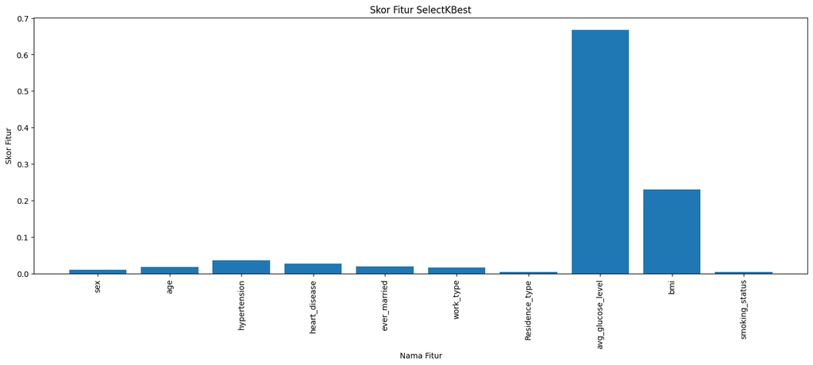

```python
import matplotlib.pyplot as plt

# Tampilkan skor fitur dalam grafik
plt.figure(figsize=(18, 6))
plt.bar(fitur_names, scores)
plt.xlabel("Nama Fitur")
plt.ylabel("Skor Fitur")
plt.title("Skor Fitur SelectKBest")
plt.xticks(rotation=90)
plt.show()
```

# 3 3. DATA PREPROCESSING

Setelah memahami data, akan dilakukan tahap preprocessing untuk menangani masalah pada data yang sudah didefinisikan pada data understanding, yakni: 1. Menghapus Data Duplikat 2. Menghapus Outlier

Setelah data siap, akan dilakukan : 1. Skoring tiap fitur kembali 2. Normalisasi Data 3. Eksplorasi Model

## 3.1 Load Dataset

meng import/memanggil dataset stroke

```python
import pandas as pd

data = pd.read_csv('stroke_data.csv')
data.head(5)
```

|  | sex | age | hypertension | heart_disease | ever_married | work_type | Residence_type | avg_glucose_level | bmi | smoking_status | stroke |
| --- | --- | --- | --- | --- | --- | --- | --- | --- | --- | --- | --- |
| 0 | 1.0 | 63.0 | 0 | 1 | 1 | 4 | 1 | 228.69 | 36.6 | 1 | 1 |
| 1 | 1.0 | 42.0 | 0 | 1 | 1 | 4 | 0 | 105.92 | 32.5 | 0 | 1 |
| 2 | 0.0 | 61.0 | 0 | 0 | 1 | 4 | 1 | 171.23 | 34.4 | 1 | 1 |
| 3 | 1.0 | 41.0 | 1 | 0 | 1 | 3 | 0 | 174.12 | 24.0 | 0 | 1 |
| 4 | 1.0 | 85.0 | 0 | 0 | 1 | 4 | 1 | 186.21 | 29.0 | 1 | 1 |

```python
# Rincian dataset (banyak data dan kolom)

print("Banyaknya data : ", data.shape[0])
print("Banyaknya kolom : ", data.shape[1])
```

```
Banyaknya data :  40910
Banyaknya kolom :  11
```

## 3.2 Menghapus Data Duplikat

```python
# Menghapus data yang duplikat
data_bersih = data.drop_duplicates()

print("Banyaknya sisa data : ", data_bersih.shape[0])
```

```
Banyaknya sisa data :  40909
```

## 3.3 Menghapus Outlier

```python
# Menghapus data outlier dari DataFrame 'data'
data_cleaned = data.drop(outlier_indices)

# Menampilkan DataFrame setelah menghapus outlier
print("Data setelah menghapus outlier:")

# Rincian dataset (banyak data dan kolom)
print("Banyaknya data : ", data_cleaned.shape[0])
```

```
Data setelah menghapus outlier:
Banyaknya data :  40639
```

setelah mehapus data outlier data dibagi menjadi fitur dan target dimana pada variabel fitur berisikan colom colom dalam dataset selain colom stroke karena stroke masuk kedalam target

```python
fitur = data_cleaned.drop(columns=['stroke'])
target = data_cleaned['stroke']

target.value_counts()
```

```
stroke
1    20447
0    20192
Name: count, dtype: int64
```

dikarenakan data classification tidak mengalami ketidakeseimabangan data, maka tidak perlu melakukan penyeimbangan data target.

## 3.4 Eksplorasi Data (Skoring Fitur)

Mengindentifikasi fitur - fitur yang ada pada dataset stroke dengan tujuan menggunakan seleksi fitur dan menampilkan grafik

```
Fitur yang terpilih: ['age', 'hypertension', 'heart_disease', 'ever_married', 'avg_glucose_level', 'bmi']
Fitur 0: sex, Skor: 0.006475888186678214
Fitur 1: age, Skor: 0.021634704500717028
Fitur 2: hypertension, Skor: 0.03728836147600867
Fitur 3: heart_disease, Skor: 0.0243301281864845
Fitur 4: ever_married, Skor: 0.021206592921776624
Fitur 5: work_type, Skor: 0.015730011293517032
Fitur 6: Residence_type, Skor: 0.001068013732904216
Fitur 7: avg_glucose_level, Skor: 0.6674888922705748
Fitur 8: bmi, Skor: 0.2307131355266958
Fitur 9: smoking_status, Skor: 0.006189423883260714
   hypertension  heart_disease  ever_married  avg_glucose_level
0             0              1             1             228.69
1             0              1             1             105.92
2             0              0             1             171.23
3             1              0             1             174.12
4             0              0             1             186.21
```

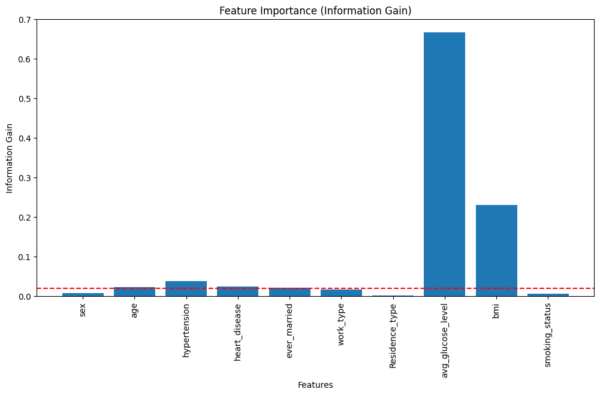

```python
import matplotlib.pyplot as plt

# Ambang skor untuk pemilihan fitur
threshold = 0.02  # Gantilah dengan ambang yang diinginkan

fitur = data_cleaned.drop(columns=['stroke'], axis=1)
target = data_cleaned['stroke']

# Buat objek SelectKBest dengan mutual_info_classif sebagai fungsi skor
k_best = SelectKBest(score_func=mutual_info_classif, k='all')

# Hitung skor fitur
k_best.fit(fitur, target)
scores = k_best.scores_

# Dapatkan nama fitur dari kolom data Anda
fitur_names = fitur.columns

# Pilih fitur yang memiliki skor di atas ambang
selected_features = [fitur_name for fitur_name, score in zip(fitur_names, scores) if score > threshold]

# Tampilkan fitur yang terpilih
print("Fitur yang terpilih:", selected_features)

# Drop fitur yang tidak terpilih
fitur_selected = fitur[selected_features]

# Tampilkan skor fitur berserta namanya
for i, (score, fitur_name) in enumerate(zip(scores, fitur_names)):
    print(f"Fitur {i}: {fitur_name}, Skor: {score}")

# Hapus fitur yang memiliki skor di bawah ambang
fitur_selected = fitur_selected[[fitur_name for fitur_name, score in zip(selected_features, scores) if score > threshold]]

# Tampilkan data setelah pemilihan fitur
print(fitur_selected.head())

# Tampilkan grafik skor fitur
plt.figure(figsize=(12, 6))
plt.bar(range(len(fitur_names)), scores)
plt.xticks(range(len(fitur_names)), fitur_names, rotation=90)
plt.xlabel('Features')
plt.ylabel('Information Gain')
plt.title('Feature Importance (Information Gain)')
plt.axhline(y=threshold, color='r', linestyle='--', label='Ambang')
plt.show()
```

```python
# Hapus fitur yang tidak terpilih dari data_cleaned
data_cleaned_selected = data_cleaned[selected_features + ['stroke']]

# Tampilkan data setelah pemilihan fitur
print(data_cleaned_selected.head())
```

```
    age  hypertension  heart_disease  ever_married  avg_glucose_level   bmi  \
0  63.0             0              1             1             228.69  36.6
1  42.0             0              1             1             105.92  32.5
2  61.0             0              0             1             171.23  34.4
3  41.0             1              0             1             174.12  24.0
4  85.0             0              0             1             186.21  29.0

   stroke
0       1
1       1
2       1
3       1
4       1
```

```python
# Menyimpan DataFrame yang terpilih ke dalam dataset_baru.csv
dataset_baru = "dataset_baru.csv"
data_cleaned_selected.to_csv(dataset_baru, index=False)

# Menampilkan pesan bahwa penyimpanan berhasvil
print(data_cleaned_selected.head())
```

```
    age  hypertension  heart_disease  ever_married  avg_glucose_level   bmi  \
0  63.0             0              1             1             228.69  36.6
1  42.0             0              1             1             105.92  32.5
2  61.0             0              0             1             171.23  34.4
3  41.0             1              0             1             174.12  24.0
4  85.0             0              0             1             186.21  29.0

   stroke
0       1
1       1
2       1
3       1
4       1
```

```
Fitur yang terpilih:
['age', 'hypertension', 'heart_disease', 'ever_married', 'avg_glucose_level', 'bmi']
```

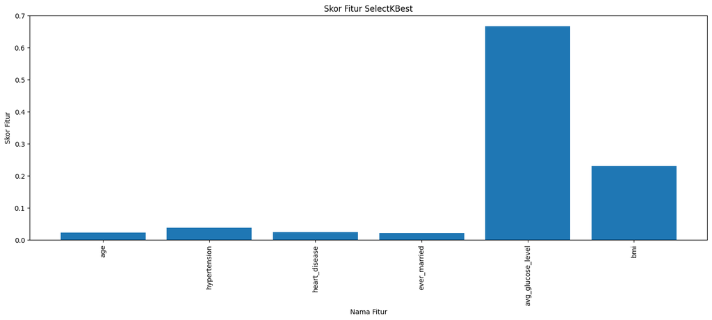

```python
import matplotlib.pyplot as plt

# Tampilkan fitur yang terpilih
selected_feature_names = [fitur_name for fitur_name, score in zip(fitur_names, scores) if score > threshold]
print("Fitur yang terpilih:")
print(selected_feature_names)

# Tampilkan skor fitur dalam grafik
plt.figure(figsize=(18, 6))
plt.bar(selected_feature_names, [score for score in scores if score > threshold])
plt.xlabel("Nama Fitur")
plt.ylabel("Skor Fitur")
plt.title("Skor Fitur SelectKBest")
plt.xticks(rotation=90)
plt.show()
```

## 3.5 Split Data

proses memisahkan dataset menjadi dua atau lebih bagian yang berbeda. Tujuan umumnya adalah untuk menggunakan satu bagian data sebagai data pelatihan (training data) untuk melatih model, dan bagian lainnya sebagai data pengujian (testing data) untuk menguji kinerja model.

```python
from sklearn.model_selection import train_test_split

# melakukan pembagian dataset, dataset dibagi menjadi 80% data training dan 20% data testing
fitur_train, fitur_test, target_train, target_test = train_test_split(fitur, target, test_size = 0.2, random_state=42)
```

## 3.6 Normalisasi Data

proses pengubahan nilai-nilai dalam suatu dataset menjadi rentang skala tertentu atau memastikan bahwa nilai-nilai tersebut mengikuti distribusi yang dapat meningkatkan kinerja beberapa algoritma machine learning.

### 3.6.1 Menggunakan Standarscaler (zscore)

Normalisasi menggunakan Z-Score atau Standard Scaler adalah salah satu teknik normalisasi yang umum digunakan dalam pengolahan data dan machine learning. Normalisasi ini mengubah setiap nilai dalam dataset sehingga memiliki rata-rata nol dan deviasi standar satu. Hal ini membantu untuk menghilangkan perbedaan skala antar fitur, membuat data lebih mudah diinterpretasikan, dan meningkatkan performa beberapa algoritma machine learning. Berikut adalah penjelasan lebih detail tentang Normalisasi Standar atau Z-Score:

**Langkah-langkah Normalisasi Standar (Z-Score):**

1. **Hitung Rata-rata dan Deviasi Standar:** Untuk setiap fitur dalam dataset, hitung rata-rata $\mu$ dan deviasi standar $\sigma$.

   $$Z = \frac{X - \mu}{\sigma}$$

   Di sini, $X$ adalah nilai individu, $\mu$ adalah rata-rata fitur, dan $\sigma$ adalah deviasi standar fitur.

Berikut adalah contoh penggunaan metode Standard Scaling (Z-Score Normalization) pada data kolom X yang berbeda:

Diberikan tabel dengan kolom X berikut:

[output not shown]

   Sehingga, hasil normalisasi (X’) untuk contoh ini adalah:

[output not shown]

Ini adalah contoh penggunaan Standard Scaling pada data kolom X yang berbeda.

```python
import pickle
from sklearn.preprocessing import StandardScaler

# membuat dan melatih objek StandardScaler
zscore_scaler = StandardScaler()
zscore_scaler.fit(fitur_train)

with open('zscorescaler_baru.pkl', 'wb') as file:
    pickle.dump(zscore_scaler, file)
# menerapkan normalisasi zscore pada data training
zscore_training = zscore_scaler.transform(fitur_train)

# menerapkan normalisasi zscore pada data testing
zscore_testing = zscore_scaler.transform(fitur_test)
```

### 3.6.2 Menggunakan Minmaxscaler

MinMax Normalization atau MinMax Scaling digunakan untuk mengubah nilai-nilai dalam suatu fitur ke dalam rentang tertentu, biasanya antara 0 dan 1. MinMax Normalization mengubah setiap nilai X dalam fitur ke dalam rentang yang diinginkan menggunakan rumus berikut:

**Langkah-langkah Normalisasi Minmax:**

1. Identifikasi Rentang: Tentukan rentang nilai yang ingin Anda gunakan. Biasanya, dalam Min-Max Scaling, rentang nilai yang dipilih adalah 0 hingga 1, tetapi ini bisa disesuaikan tergantung pada kasus penggunaan.
2. Hitung Nilai Minimum dan Maksimum: Tentukan nilai minimum (min) dan nilai maksimum (max) dari setiap fitur dalam kumpulan data yang akan dinormalisasi.
3. Normalisasi: Gunakan formula rumusn Min-Max Scaling untuk mengubah nilai-nilai dalam rentang yang ditentukan.

Rumus Minmax Scaler

$$X' = \frac{X-Xmin}{Xmax - Xmin}$$

Dimana : - X adalah nilai asli dari suatu kolom/fitur - min adalah nilai minimum dari suatu kolom/fitur dalam dataset - max adalah nilai maximum dari suatu kolom/fitur dalam dataset - X’ adalah nilai X yang telah dinormalisasi.

Berikut adalah contoh penggunaan Min-Max Scaling pada data kolom X yang berbeda:

Diberikan tabel dengan kolom X berikut:

[output not shown]

Untuk melakukan normalisasi dengan Min-Max Scaling, kita perlu mengidentifikasi nilai terendah dan tertinggi pada kolom. Dalam kasus ini:

- Nilai terendah pada kolom X (min) = 5
- Nilai tertinggi pada kolom X (max) = 20

Sehingga, nilai X’ hasil normalisasi dapat dihitung seperti berikut:

[output not shown]

Jadi, nilai X’ hasil normalisasi untuk contoh ini adalah:

[output not shown]

Ini adalah contoh penggunaan Min-Max Scaling pada data kolom X yang berbeda.

```python
from sklearn.preprocessing import MinMaxScaler


# membuat dan melatih objek MinMaxScaler
minmaxscaler = MinMaxScaler()
minmaxscaler.fit(fitur_train)

# menerapkan normalisasi zscore pada data training
minmax_training = minmaxscaler.transform(fitur_train)

# menerapkan normalisasi zscore pada data testing
minmax_testing = minmaxscaler.transform(fitur_test)
```

## 3.7 4. MODELING

### 3.7.1 Menggunakan Random Forest

random Forest adalah algoritma pembelajaran terawasi yang digunakan untuk tugas klasifikasi dan regresi dalam machine learning. Ini merupakan bagian dari keluarga algoritma yang dikenal sebagai ensemble learning, yang menggabungkan hasil beberapa model untuk meningkatkan kinerja dan ketepatan prediksi.

Konsep inti dari Random Forest adalah membuat sejumlah besar pohon keputusan saat melakukan prediksi. Setiap pohon keputusan dibuat berdasarkan sampel acak dari data pelatihan dan fitur yang dipilih secara acak. Proses ini mengurangi risiko overfitting (memfitting data pelatihan secara berlebihan) yang sering terjadi pada pohon keputusan tunggal.

Selama proses pelatihan, setiap pohon keputusan dalam hutan acak memilih subset data yang diambil secara acak dan subset fitur untuk membuat keputusan. Ketika melakukan prediksi, setiap pohon memberikan hasilnya, dan hasil akhir dari Random Forest diperoleh dengan mengambil mayoritas suara dari semua pohon keputusan (untuk klasifikasi) atau rerata hasil (untuk regresi).

Kelebihan dari Random Forest termasuk kemampuannya dalam menangani data yang besar dengan fitur yang banyak, serta kemampuan untuk mengatasi overfitting. Namun, seperti halnya dengan banyak algoritma machine learning, pengaturan parameter yang tidak tepat atau kekurangan pemrosesan data yang tepat dapat mempengaruhi kinerja Random Forest.

- Langkah-Langkah Random Forest:

  **1. Pembuatan Bootstrap Samples:** - Buat beberapa dataset bootstrap dari dataset pelatihan dengan pengambilan sampel dengan pengembalian.

  **2. Pembuatan Pohon:** - Bangun pohon keputusan untuk setiap dataset bootstrap. Pohon ini dibangun dengan memilih fitur secara acak pada setiap split.

  **3. Prediksi dari Setiap Pohon:** - Lakukan prediksi pada setiap pohon untuk data uji.

  **4. Klasifikasi (Voting) atau Regresi (Average):** - Untuk klasifikasi, tentukan hasil akhir menggunakan voting mayoritas. Untuk regresi, ambil rata-rata prediksi dari semua pohon.

  **5. Evaluasi Kinerja:** - Evaluasi kinerja model menggunakan metrik yang sesuai dengan tugas (misalnya, akurasi untuk klasifikasi, MSE untuk regresi).
- Rumus:

#### 3.7.1.1 Gini Index (Untuk Pohon Keputusan):

$$Gini(t) = 1 - \sum_{i=1}^{c} (p_i)^2$$

#### 3.7.1.2 Prediksi Klasifikasi (Voting):

$$\text{Prediction} = \text{argmax}(\text{votes})$$

#### 3.7.1.3 Prediksi Regresi (Average):

$$\text{Prediction} = \frac{1}{N} \sum_{i=1}^{N} y_i$$

Di sini, $t$ adalah node dalam pohon, $c$ adalah jumlah kelas, $p_i$ adalah proporsi sampel di kelas $i$, $N$ adalah jumlah pohon dalam ensemble, dan $y_i$ adalah prediksi pohon ke-$i$.

Pada bagian ini menggunakan normalisasi zscore untuk membuat model

```python
from sklearn.ensemble import RandomForestClassifier
from sklearn.model_selection import GridSearchCV
from sklearn.metrics import accuracy_score
import pickle
import numpy as np

# Define the parameter grid for Random Forest
param_grid = {
    'n_estimators': [50, 100],  # Reduced number of trees
    'max_depth': [None, 5, 10],  # Reduced maximum depth of each tree
    'min_samples_split': [2, 5, 10],
    'min_samples_leaf': [1, 2, 4]
}

zscore_training1 = np.delete(zscore_training, [0, 5, 6, 9], axis=1)
zscore_testing1 = np.delete(zscore_testing, [0, 5, 6, 9], axis=1)


# Create a Random Forest model
random_forest = RandomForestClassifier()

# MINMAX
grid_search1 = GridSearchCV(estimator=random_forest, param_grid=param_grid, cv=5, scoring='accuracy')
grid_search1.fit(zscore_training1, target_train)
print("Best Parameters ZSCORE:", grid_search1.best_params_)
best_n_estimators_zscore = grid_search1.best_params_['n_estimators']
best_max_depth_zscore = grid_search1.best_params_['max_depth']
best_min_samples_split_zscore = grid_search1.best_params_['min_samples_split']
best_min_samples_leaf_zscore = grid_search1.best_params_['min_samples_leaf']

# Membuat model RandomForest dengan parameter terbaik
model_rf_zscore = RandomForestClassifier(
    n_estimators=best_n_estimators_zscore,
    max_depth=best_max_depth_zscore,
    min_samples_split=best_min_samples_split_zscore,
    min_samples_leaf=best_min_samples_leaf_zscore
)

# Melatih model dengan data pelatihan
model_rf_zscore.fit(zscore_training1, target_train)

# Melakukan prediksi pada data uji dengan normalisasi zscore
y_pred_zscore = model_rf_zscore.predict(zscore_testing1)

# Mengukur akurasi dengan normalisasi zscore pada data uji
accuracy_rf_zscore = accuracy_score(target_test, y_pred_zscore)

print("AKURASI RANDOM FOREST")
print("AKURASI ZSCORE :", accuracy_rf_zscore)

# Menyimpan model yang telah di-fit dengan parameter terbaik
path_rf = 'gridrandomforestzscore.pkl'
with open(path_rf, 'wb') as model_file:
    pickle.dump(model_rf_zscore, model_file)
```

```
Best Parameters ZSCORE: {'max_depth': None, 'min_samples_leaf': 1, 'min_samples_split': 2, 'n_estimators': 50}
AKURASI RANDOM FOREST
AKURASI ZSCORE : 0.9923720472440944
```

### 3.7.2 —EVALUASI MODEL—

Pada tahap ini model terbaik yang diperoleh pada tahap modeling dilakukan validasi dengan menampilkan nilai confusion matrix nya atau laporan klasifikasinya dengan menggunakan grafik ROC-AUC

### 3.7.3 CONFUSION MATRIX

Confusion matrix adalah sebuah tabel yang digunakan dalam evaluasi kinerja model klasifikasi untuk memahami performa model dalam memprediksi kelas-kelas target. Matrix ini memiliki empat sel yang mewakili:

1. True Positive (TP): Prediksi yang benar ketika kelas sebenarnya adalah positif.
2. True Negative (TN): Prediksi yang benar ketika kelas sebenarnya adalah negatif.
3. False Positive (FP): Prediksi yang salah ketika model memprediksi positif tetapi kelas sebenarnya negatif (juga dikenal sebagai Type I error).
4. False Negative (FN): Prediksi yang salah ketika model memprediksi negatif tetapi kelas sebenarnya positif (juga dikenal sebagai Type II error).

Bentuk dari tabel Confusion Matrix

|  | Predicted Negative | Predicted Positive |
| --- | --- | --- |
| Actual Negative | True Negative (TN) | False Positive (FP) |
| Actual Positive | False Negative (FN) | True Positive (TP) |

Dari Confusion Matriks, kta dapat menghitung metrik evaluasi seperti akurasi, presisi, recall, F1-score, dan lainnya yang membantu dalam mengevaluasi performa model klasifikasi.

#### 3.7.3.1 Metrik Evaluasi

Metrik evaluasi adalah ukuran atau parameter yang digunakan untuk mengevaluasi kinerja suatu model atau sistem dalam melakukan tugas tertentu, seperti klasifikasi, regresi, atau tugas lainnya dalam bidang machine learning dan statistika. Metrik-metrik ini membantu dalam memahami seberapa baik atau buruk model tersebut dalam melakukan prediksi atau tugas yang ditetapkan.

```python
from sklearn.metrics import accuracy_score, precision_score, recall_score, f1_score

def evaluate_model(y_true, y_pred, model_name, scaler_name):
    accuracy = accuracy_score(y_true, y_pred)
    precision = precision_score(y_true, y_pred, average='weighted')
    recall = recall_score(y_true, y_pred, average='weighted')
    f1 = f1_score(y_true, y_pred, average='weighted')

    print(f"\nModel {model_name} Menggunakan {scaler_name}:")
    print(f'Akurasi: {accuracy:.2f}')
    print(f'Presisi: {precision:.2f}')
    print(f'Recall: {recall:.2f}')
    print(f'F1-Score: {f1:.2f}')

# Evaluasi model Random Forest dengan zscorescaler
evaluate_model(target_test, y_pred_zscore, "Random Forest", "zscoreScaler")
```

```
Model Random Forest Menggunakan zscoreScaler:
Akurasi: 0.99
Presisi: 0.99
Recall: 0.99
F1-Score: 0.99
```

```python
from sklearn.metrics import confusion_matrix, classification_report, roc_auc_score,roc_curve

# Evaluasi model dengan data uji Z-score
print("\nEVALUASI MODEL DENGAN DATA UJI Z-score")
print("Confusion Matrix Z-score:")
conf_matrix = confusion_matrix(target_test, y_pred_zscore)
print(conf_matrix)

# Mendapatkan nilai TP, TN, FP, FN dari confusion matrix
TN = conf_matrix[0, 0]
FP = conf_matrix[0, 1]
FN = conf_matrix[1, 0]
TP = conf_matrix[1, 1]

print("\nTrue Positive (TP):", TP)
print("True Negative (TN):", TN)
print("False Positive (FP):", FP)
print("False Negative (FN):", FN)

print("\nClassification Report Z-score:")
print(classification_report(target_test, y_pred_zscore))
print("ROC-AUC Score Z-score:", roc_auc_score(target_test, y_pred_zscore))
```

```
EVALUASI MODEL DENGAN DATA UJI Z-score
Confusion Matrix Z-score:
[[3990   59]
 [   3 4076]]

True Positive (TP): 4076
True Negative (TN): 3990
False Positive (FP): 59
False Negative (FN): 3

Classification Report Z-score:
              precision    recall  f1-score   support

           0       1.00      0.99      0.99      4049
           1       0.99      1.00      0.99      4079

    accuracy                           0.99      8128
   macro avg       0.99      0.99      0.99      8128
weighted avg       0.99      0.99      0.99      8128

ROC-AUC Score Z-score: 0.9923465132417175
```

Ada beberapa poin yang perlu diperhatikan :

1. Akurasi
2. Presisi mengukur sejauh mana hasil positif yang diprediksi oleh model adalah benar.
3. Recall Recall mengukur sejauh mana model dapat mengidentifikasi dengan benar semua instance positif dalam data.
4. F1-Score adalah metrik gabungan yang mempertimbangkan presisi dan recall.

Metrik evaluasi ROC (Receiver Operating Characteristic) dan AUC (Area Under the ROC Curve) adalah alat evaluasi yang digunakan untuk mengukur kinerja model klasifikasi, terutama ketika model harus mengklasifikasikan antara dua kelas.

#### 3.8.0.1 Receiver Operating Characteristic (ROC) Curve

ROC Curve adalah adalah kurva grafik yang menampilkan kinerja model klasifikasi pada berbagai tingkat cutoff (threshold) untuk membedakan antara kelas positif dan negatif. Didalam ROC kurva dapat diketahui sensitivity (True Positive Rate) dan False Positive Rate (1-Specificity), untuk menunjukkan seberapa baik model klasifikasi sehingga dapat membedakan antara kelas positif dan negatif.

#### 3.8.0.2 Area Under the ROC Curve (AUC-ROC):

AUC-ROC adalah ukuran dari luas area di bawah kurva ROC. - Interpretasi : Nilai AUC berkisar antara 0 hingga 1. Semakin dekat nilainya ke 1, semakin baik model dalam membedakan antara kelas positif dan negatif. Jika nilainya 0.5, itu menunjukkan klasifikasi acak.

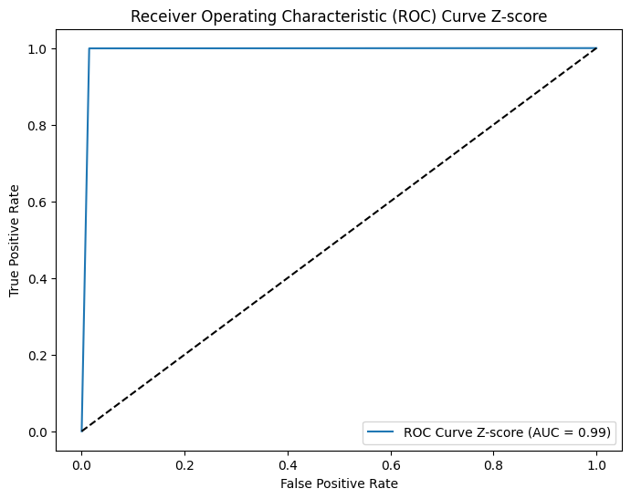

```python
from sklearn.metrics import roc_curve, roc_auc_score
import matplotlib.pyplot as plt

# Pastikan label positif Anda adalah 1
pos_label = 1

# Kurva ROC-AUC untuk model dengan data uji z-score
fpr_zscore, tpr_zscore, thresholds_zscore = roc_curve(target_test, y_pred_zscore, pos_label=pos_label)
plt.figure(figsize=(8, 6))
plt.plot(fpr_zscore, tpr_zscore, label='ROC Curve Z-score (AUC = %0.2f)' % roc_auc_score(target_test, y_pred_zscore))
plt.plot([0, 1], [0, 1], 'k--')
plt.xlabel('False Positive Rate')
plt.ylabel('True Positive Rate')
plt.title('Receiver Operating Characteristic (ROC) Curve Z-score')
plt.legend(loc='lower right')
plt.show()
```

# 4 — DEPLOYMENT —

code dilanjut pada file main.py untuk membangun sistem